# L04_Joseph_Armijo_ITAI4374

## PART A — Setup and Your First LIF Neuron

Imports

```python
import numpy as np
import matplotlib.pyplot as plt

print("Setup complete!")
```

```
Setup complete!
```

Simulation Parameters

```python
# ============ Simulation Parameters ============
dt = 0.001  # Time step (1 ms)
T = 1.0     # Total simulation time (1 second)
time = np.arange(0, T, dt)

# ============ Neuron Parameters ============
V_rest = -70.0     # Resting potential (mV)
V_thresh = -70.0   # Spike threshold (mV)
V_reset = -75.0    # Reset potential after spike (mV)
tau = 0.020        # Membrane time constant (20 ms)
C = 1.0            # Membrane capacitance

print(f"Simulation: {T}s with {len(time)} time steps")
print(f"Threshold: {V_thresh} mV, Rest: {V_rest} mV")
```

```
Simulation: 1.0s with 1000 time steps
Threshold: -70.0 mV, Rest: -70.0 mV
```

### Knowledge Check

1. Why is V_reset (-75 mV) lower than V_rest (-70 mV)? What biological phenomenon does this represent?

Following a spike, real neurons go into an after-hyperpolarization phase, in which the membrane potential is more negative than at rest. This is due to the opening of the potassium channels, making the neuron less excitable.

2. The time constant tau is 20 ms. In plain English, what does this control?

The time constant determines the speed at which the membrane potential responds to input.

- If tau is small, the membrane voltage changes quickly, making sharp changes.
- If tau is large, the membrane voltage changes slowly, making smooth changes.

In other words, the time constant controls how sluggish or responsive the neuron is.

LIF Neuron Simulation

```python
# ============ Input Current ============
I_input = np.zeros(len(time))
I_input[200:800] = 15.0  # Inject current from 200ms to 800ms
```

```python
# ============ Storage Arrays ============
V = np.zeros(len(time))
V[0] = V_rest

spikes = []
```

```python
# ============ Simulation Loop ============
for t in range(len(time) - 1):

    # Compute voltage change
    dV = dt * (-(V[t] - V_rest) / tau + I_input[t] / C)

    # Update voltage
    V[t+1] = V[t] + dV

    # Check for spike
    if V[t+1] >= V_thresh:
        spikes.append(time[t+1])
        V[t+1] = V_reset

print(f"Neuron fired {len(spikes)} spikes")
```

```
Neuron fired 12 spikes
```

Plot Membrane Potential

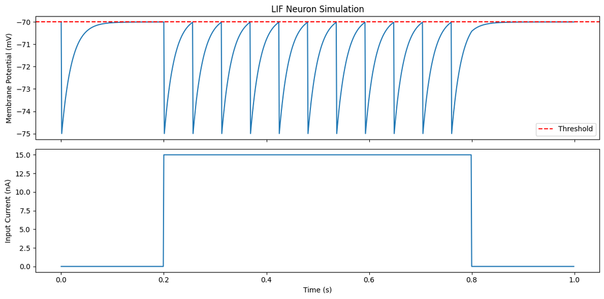

```python
fig, (ax1, ax2) = plt.subplots(2, 1, figsize=(12,6), sharex=True)

# Membrane potential
ax1.plot(time, V)
ax1.axhline(y=V_thresh, color='r', linestyle='--', label='Threshold')
ax1.set_ylabel("Membrane Potential (mV)")
ax1.set_title("LIF Neuron Simulation")
ax1.legend()

# Input current
ax2.plot(time, I_input)
ax2.set_ylabel("Input Current (nA)")
ax2.set_xlabel("Time (s)")

plt.tight_layout()
plt.show()
```

### Knowledge Check

1. Look at your membrane potential plot. What happens to V between spikes? Does it go straight up or curve?

Between these spikes, the voltage increases in a curving line, not a straight line. This is due to the fact that the leak term in the LIF equation causes the voltage to seek rest and this results in an exponential rise.

2. What happens to V after the current turns off at 800 ms? Why?

Once the current is removed at 800 ms, the voltage returns smoothly to the resting potential due to the leak term.

## Reflection

Look at your membrane potential trace. In the booklet, you learned that biological neurons show similar integrate-and-fire behavior. What aspects of your plot look “realistic” compared to what you read about real neurons? What looks overly simplified?

The membrane potential trace is realistic because it has integration, threshold, and reset properties. The trace is simple because it doesn’t have dendritic processes, ion channels, and refractory periods.

## PART B — Encoding Data as Spikes

Rate Coding

```python
def rate_encode(values, num_steps=100):

    num_neurons = len(values)
    spikes = np.zeros((num_steps, num_neurons))

    for t in range(num_steps):
        spikes[t] = (np.random.rand(num_neurons) < values).astype(float)

    return spikes
```

Test Rate Coding

```python
test_values = np.array([0.1, 0.3, 0.5, 0.7, 0.9])
test_spikes = rate_encode(test_values, num_steps=200)

for i, v in enumerate(test_values):
    count = test_spikes[:, i].sum()
    print(f"Value {v:.1f} -> {count:.0f} spikes in 200 steps")
```

```
Value 0.1 -> 14 spikes in 200 steps
Value 0.3 -> 61 spikes in 200 steps
Value 0.5 -> 98 spikes in 200 steps
Value 0.7 -> 135 spikes in 200 steps
Value 0.9 -> 176 spikes in 200 steps
```

Temporal Coding

```python
def temporal_encode(values, num_steps=100, threshold=0.05):

    num_neurons = len(values)
    spikes = np.zeros((num_steps, num_neurons))

    for i in range(num_neurons):

        if values[i] > threshold:

            spike_time = int((1 - values[i]) * (num_steps - 1))

            spikes[spike_time, i] = 1

    return spikes
```

### Knowledge Check

1. In rate coding, what information is lost about the original signal?

In rate coding, the time at which the spikes occurred is lost. It only records the rate at which the neurons are firing, not the time at which the signals are occurring.

2. Why might temporal coding allow faster decisions?

Temporal coding uses the time to the first spike to represent the information. This is why the system doesn't have to wait for the rate to be established; the first spike is enough to represent the information.

3. Can you think of a real-world example where timing matters more than frequency?

A real-life scenario I think that can illustrate the difference between the two types of coding is the detection of the motion of an object. In the detection of the motion of an object, the exact timing of the spikes is important. Neighboring neurons have spikes that occur at precise times, which helps the brain determine the direction of the motion of the object.

## PART C — Raster Plot Comparison

Raster Plots

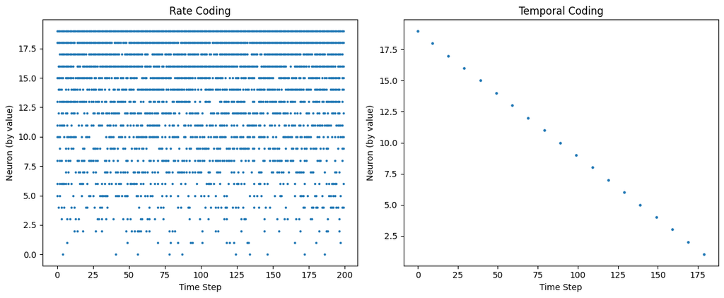

```python
signal = np.linspace(0.05, 1.0, 20)

rate_spikes = rate_encode(signal, num_steps=200)
temp_spikes = temporal_encode(signal, num_steps=200)

fig, (ax1, ax2) = plt.subplots(1,2, figsize=(12,5))

# Rate coding raster
times, neurons = np.where(rate_spikes == 1)
ax1.scatter(times, neurons, s=3)
ax1.set_title("Rate Coding")
ax1.set_xlabel("Time Step")
ax1.set_ylabel("Neuron (by value)")

# Temporal coding raster
times, neurons = np.where(temp_spikes == 1)
ax2.scatter(times, neurons, s=5)
ax2.set_title("Temporal Coding")
ax2.set_xlabel("Time Step")
ax2.set_ylabel("Neuron (by value)")

plt.tight_layout()
plt.show()
```

## REFLECTION

Compare your two raster plots. Which encoding would be better for a system that needs to react quickly? Which would be better for a system that needs precise measurements? The brain uses both strategies in different circuits — why do you think that is?

Temporal coding would be appropriate in a system that has to respond rapidly, since the timing of the first spike is used to encode the information, and a decision can be made almost instantaneously. Rate coding would be appropriate in a system in which accurate measurement is necessary, since the average of many spikes is a reliable and noise-resistant measurement of the signal's intensity. Both methods are used in the brain because different systems have different needs, and some systems, like those used in motion detection, need to respond rapidly, while others, like those used in perception and decision-making, need to be accurate.

## PART C — Mini Spiking Neural Network

Network Setup

```python
N = 5
T_net = 0.5
time_net = np.arange(0, T_net, dt)
steps = len(time_net)

weights = np.zeros((N, N))

weights[0,2] = 12.0
weights[1,3] = 12.0
weights[2,4] = 10.0
weights[3,4] = 10.0

I_ext = np.zeros((steps, N))

I_ext[100:400,0] = 18.0
I_ext[150:350,1] = 18.0

V_net = np.full((steps, N), V_rest)

spike_log = [[] for _ in range(N)]
```

Network Simulation

```python
for t in range(steps - 1):

    # Track neurons that spike at this timestep
    spiked_now = np.zeros(N)

    for n in range(N):

        # External input current
        I_total = I_ext[t, n]

        # Synaptic input from neurons that spiked in previous step
        for j in range(N):
            if len(spike_log[j]) > 0:
                if spike_log[j][-1] == time_net[t]:
                    I_total += weights[j, n]

        # LIF voltage update
        dV = dt * (-(V_net[t, n] - V_rest) / tau + I_total / C)

        V_net[t+1, n] = V_net[t, n] + dV

        # Spike detection
        if V_net[t+1, n] >= V_thresh:
            spike_log[n].append(time_net[t+1])
            V_net[t+1, n] = V_reset
            spiked_now[n] = 1

for n in range(N):

    print(f"Neuron {n}: {len(spike_log[n])} spikes")
```

```
Neuron 0: 7 spikes
Neuron 1: 5 spikes
Neuron 2: 3 spikes
Neuron 3: 3 spikes
Neuron 4: 3 spikes
```

## Network Visualization

Network Raster Plot

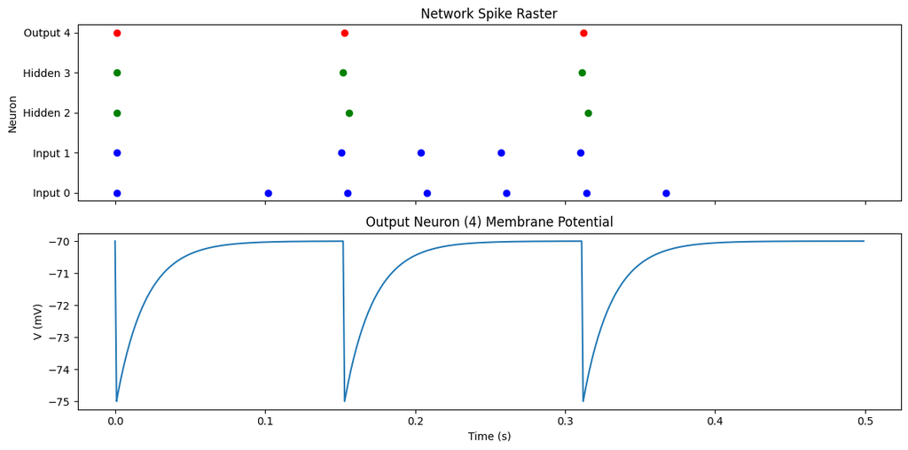

```python
fig, (ax1, ax2) = plt.subplots(2,1, figsize=(12,6), sharex=True)

colors = ['blue','blue','green','green','red']

for n in range(N):
    ax1.scatter(spike_log[n], [n]*len(spike_log[n]), color=colors[n])

ax1.set_ylabel("Neuron")
ax1.set_title("Network Spike Raster")

ax1.set_yticks(range(N))
ax1.set_yticklabels(['Input 0','Input 1','Hidden 2','Hidden 3','Output 4'])

ax2.plot(time_net, V_net[:,4])

ax2.set_ylabel("V (mV)")
ax2.set_xlabel("Time (s)")
ax2.set_title("Output Neuron (4) Membrane Potential")

plt.tight_layout()
plt.show()
```

Knowledge Check

1. Does the output neuron fire at the same rate as the input neurons? Why or why not?

The output neuron fires less because it only fires when it receives enough combined excitatory inputs from neurons 2 and 3. Since it is dependent on the activity of the other neurons rather than receiving a direct external current, the output neuron fires less often than the input neurons.

2. What role do the synaptic weights play? What would happen if you doubled them? Halved them?

The synaptic weights control the strength of the interactions between the neurons. The greater the weight, the greater the likelihood that the output neuron will fire. The lower the weight, the lower the likelihood that the output neuron will fire. If the synaptic weights were doubled, the output neuron would fire more often; if the synaptic weights were halved, the output neuron would fire less often.

3. In the brain, not all connections are excitatory. What might happen if you made weights[3, 4] negative (inhibitory)?

If the synaptic weight between neurons 3 and 4 is made inhibitory, the output will not spike, since the inhibitory input will cancel the excitatory input coming from neuron 2.

## PART D — Experiments

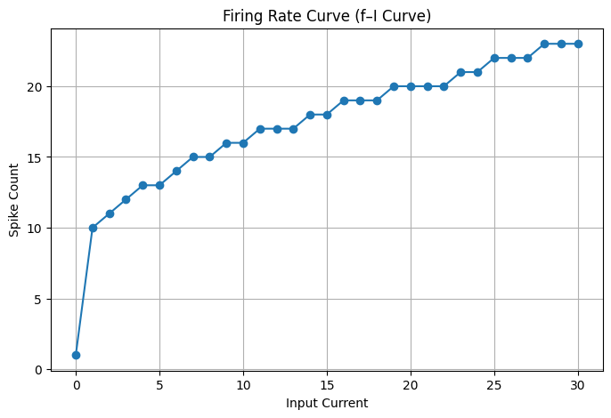

```
Firing rate sweep completed.
```

```python
# =====================================
# Experiment 1: Firing Rate Curve (f-I Curve)
# Sweep Input Current 0 → 30
# =====================================

current_values = np.arange(0, 31, 1)
spike_counts = []

for I_test in current_values:

    V = V_rest
    spike_count = 0

    for t in range(len(time)-1):

        dV = dt * (-(V - V_rest)/tau + I_test/C)
        V = V + dV

        if V >= V_thresh:
            spike_count += 1
            V = V_reset

    spike_counts.append(spike_count)

# Plot f-I curve
plt.figure(figsize=(8,5))
plt.plot(current_values, spike_counts, marker='o')

plt.xlabel("Input Current")
plt.ylabel("Spike Count")
plt.title("Firing Rate Curve (f–I Curve)")
plt.grid()
plt.show()

print("Firing rate sweep completed.")
```

### Experiment 1

1. What parameter did you change?

In this experiment, I changed the input current to the neuron. The current was swept from 0 to 30 in steps of 1 to observe how the firing rate changes.

2. What did you expect to happen?

I expected that when the input current increased, the neuron would fire more spikes. A stronger input should push the membrane potential to the threshold more often.

3. What actually happened?

The results matched the expectation. When the input current was very low, the neuron fired few or no spikes. As the current increased, the number of spikes increased steadily. The firing rate curve shows a clear upward trend as input current increases.

4. Why does this make sense based on the LIF equation?

The input current I directly increases the membrane potential. When the current becomes larger, the voltage reaches the firing threshold faster, which causes more spikes over time.

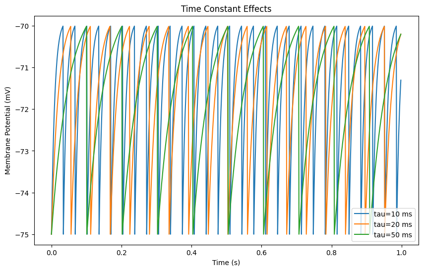

```python
# ================================
# Experiment 2: Time Constant Effects
# ================================

tau_values = [0.01, 0.02, 0.05]

I_input_const = 15.0

plt.figure(figsize=(10,6))

for tau_test in tau_values:

    V = V_rest
    V_trace = []

    for t in range(len(time)-1):

        dV = dt * (-(V - V_rest)/tau_test + I_input_const/C)
        V = V + dV

        if V >= V_thresh:
            V = V_reset

        V_trace.append(V)

    plt.plot(time[:len(V_trace)], V_trace,
             label=f"tau={tau_test*1000:.0f} ms")

plt.xlabel("Time (s)")
plt.ylabel("Membrane Potential (mV)")
plt.title("Time Constant Effects")
plt.legend()
plt.show()
```

### Experiment 2

1. What parameter did you change?

I changed the membrane time constant tau. I tested three values:

- 10 ms
- 20 ms
- 50 ms
2. What did you expect to happen?

I expected that smaller tau values would make the membrane potential respond faster to input current. Larger tau values should cause slower changes in voltage.

3. What actually happened?

The results showed that when tau was small (10 ms), the membrane potential increased more quickly between spikes. When tau was larger (50 ms), the voltage increased more slowly and the curve looked smoother.

4. Why does this make sense based on the LIF equation?

The time constant controls how quickly the voltage changes. In the LIF equation, tau determines how fast the membrane potential moves toward equilibrium. A smaller tau means faster voltage changes, while a larger tau slows down the membrane dynamics.

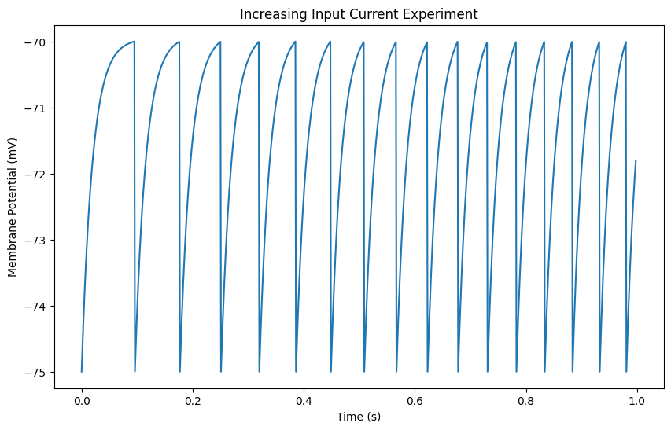

```
Spike count: 17
```

```python
# ================================
# Experiment 3: Increasing Input Current
# ================================

I_input = np.linspace(0, 25, len(time))

V = V_rest
V_trace = []
spike_times = []

for i in range(len(time)-1):

    I = I_input[i]

    dV = dt * (-(V - V_rest)/tau + I/C)
    V = V + dV

    if V >= V_thresh:
        spike_times.append(time[i])
        V = V_reset

    V_trace.append(V)

plt.figure(figsize=(10,6))
plt.plot(time[:len(V_trace)], V_trace)
plt.xlabel("Time (s)")
plt.ylabel("Membrane Potential (mV)")
plt.title("Increasing Input Current Experiment")
plt.show()

print("Spike count:", len(spike_times))
```

### Experiment 3

1. What parameter did you change?

Instead of a constant input current, I used a gradually increasing current: I_input = np.linspace(0, 25, len(time))

2. What did you expect to happen?

I expected the neuron to fire more frequently as time goes on because the input current becomes stronger.

3. What actually happened?

The results showed that spikes occurred more frequently later in the simulation as the input current increased. Early in the simulation the neuron fired less often, but as the current increased, the neuron reached the threshold more quickly.

4. Why does this make sense based on the LIF equation?

Since the input current term increases over time, it causes the membrane potential to rise faster. This allows the neuron to reach the threshold more frequently, which leads to more spikes.

## Part E: Final Reflection

1. How does changing the membrane time constant (τ) affect firing behavior? What biological property does this represent? (Think about different types of neurons in the brain.)

The change in the time constant of the membrane will influence the rate at which the neuron’s membrane potential will change in response to the input. If the time constant is smaller, the change in the voltage will occur more rapidly, thus enabling the neuron to reach the threshold more quickly. This will cause the neuron to fire more rapidly.

The biological significance of the time constant is the difference in the properties of the neuron’s membrane, such as the resistance and capacitance of the neuron’s membrane. Different neurons in the human brain have different time constants, depending on their structure and function. Some neurons respond more rapidly to stimuli, while others respond more slowly.

2. Compare your rate coding and temporal coding results. Which encoding preserved more information about the original signal? Why might the brain use both strategies in different circuits?

Rate coding conveys information based on the number of spikes over time. For my results, the more the value of the signal, the more the number of spikes. The disadvantage is that the timing of the spikes is lost.

Temporal coding stores information based on the timing of the spike. The stronger the signal, the earlier the spike is generated. This is faster in conveying information because the system does not have to wait for the rate of the spike to be generated.

The brain is likely using both rate coding and temporal coding because the brain is able to handle information in different ways depending on the task at hand.

3. In your mini SNN, what happened when spikes propagated through layers? How does this relate to how information flows through real neural circuits?

The mini spiking neural network had spikes coming from the input neuron, and this affected the hidden neuron, which in turn affected the output neuron. The spikes transmitted signals in the network based on the links and weights of the network.

This is similar to how signals are transmitted in the human body. Neurons transmit signals in the human body, and signals in one neuron may transmit signals to other neurons. The structure of the network also affects how signals are transmitted.

4. The LIF model is a simplification. What does it capture well about real neurons? What important biological features does it miss? (Think: dendrites, neurotransmitters, morphology, adaptation.)

The LIF model demonstrates some of the key aspects of the way in which real neurons behave. For example, the model demonstrates the way in which the neuron responds to the signals that are fed into it, the way in which the neuron fires in response to the accumulation of signal strength, and the way in which the neuron resets after the signal has been fired.

However, the LIF model does not demonstrate many of the key aspects of the way in which the brain works. For example, the brain is made up of many complex structures that play an important role in the way in which the brain works. Additionally, the brain uses many neurotransmitters in order to function. Furthermore, the brain is capable of adapting in many ways.

5. After building these simulations, what is one thing about biological neural computation that surprised you or changed how you think about artificial intelligence?

One thing that surprised me was the extent to which behavior could arise from very simple equations. Even the basic LIF equations produced patterns that resembled the firing of neurons. It also showed that complex behavior in neural systems can arise from very simple rules.

This also made me think differently about artificial intelligence. Neurons communicate in the brain through spikes, whereas most artificial intelligence systems use continuous numbers. I think that maybe the next step in artificial intelligence could involve more brain-like communication.